# Module R’Stat1 : TD04

francois.rebaudo@ird.fr

Novembre 2019 ; IRD-Montpellier-France CC BY-NC-ND 3.0

# TD04 : comp. ref.

## Objectifs

- A partir de moyennes de référence pour chaque mois de l’année, combien de jours par mois ont une température significativement différente de la référence ?

| Mois | Référence | Mois | Référence |
| --- | --- | --- | --- |
| Jan | 1.6 | Juil | 22.0 |
| Fev | 4.3 | Aout | 19.8 |
| Mar | 7.5 | Sep | 15.9 |
| Avr | 11.0 | Oct | 6.4 |
| Mai | 12.7 | Nov | 5.4 |
| Juin | 19.4 | Dec | 3.9 |

## Etape 01 : charger les données

```r
bdd <- read.table("./DATA/bdd.csv", header = TRUE, sep = ",", dec = ".")
head(bdd)
```

```
##   year month day hour minute second temperature      gas humidity pressure
## 1 2018    10  22   17     58      1    10.75793 11811196 80.34636 1040.177
## 2 2018    10  22   17     59     26    10.76887 11682953 79.98910 1040.153
## 3 2018    10  22   18      0     29    10.80402 11569892 79.74389 1040.090
## 4 2018    10  22   18      1     31    10.78391 11582347 79.84094 1040.164
## 5 2018    10  22   18      2     33    10.73586 11582347 80.57278 1040.286
## 6 2018    10  22   18      3     36    10.66633 11582347 81.02920 1040.477
##   lightVisible lightIR lightUV
## 1          264     318       4
## 2          266     313       5
## 3          263     306       3
## 4          267     307       4
## 5          266     308       5
## 6          266     307       5
```

## Etape 02 : mettre les valeurs de référence dans un vecteur

```r
myRef <- c(1.6, 4.3, 7.5, 11.0, 12.7, 19.4,
  22.0, 19.8, 15.9, 6.4, 5.4, 3.9)
```

## Etape 03 : séparer les valeurs de température par mois

```r
bddM <- split(bdd[c("day", "temperature")], f = bdd$month)
```

## Etape 04 : séparer les valeurs de température par mois par jour

```r
bddMD <- lapply(seq_along(bddM), function(i){
  split(bddM[[i]]$temperature, f = bddM[[i]]$day)
})
```

## Etape 05 : vérifier le nombre de jours par mois

```r
length(bddMD)
```

```
## [1] 12
```

```r
sapply(bddMD, length)
```

```
##  [1] 31 28 31 30 31 30 31 31 30 13 30 31
```

## Etape 06 : pour chaque jour de chaque mois, comparer les valeurs de température à la référence du mois

```r
for(monMois in 1:12){
  for(monJour in 1:sapply(bddMD, length)[monMois])
    t.test(bddMD[[monMois]][[monJour]], mu = myRef[monMois])
}
```

=> cela fonctionne mais nous souhaitons récupérer les données !!!

## Etape 06

```r
pvalMois <- sapply(seq_along(bddMD), function(i){
  sapply(seq_along(bddMD[[i]]), function(j){
    t.test(bddMD[[i]][[j]], mu = myRef[i])$p.value
  })
})
print(pvalMois)
```

```
## [[1]]
##  [1]  0.000000e+00  0.000000e+00  3.914406e-08  2.802675e-45 1.871134e-170
##  [6]  0.000000e+00  0.000000e+00  0.000000e+00  9.644306e-56 1.127342e-284
## [11]  7.258500e-69  0.000000e+00  0.000000e+00  0.000000e+00  0.000000e+00
## [16]  1.195319e-03  2.725660e-92  0.000000e+00  0.000000e+00  0.000000e+00
## [21]  0.000000e+00  0.000000e+00  0.000000e+00  0.000000e+00 1.101342e-147
## [26]  0.000000e+00 3.653573e-203  8.852787e-19  0.000000e+00  0.000000e+00
## [31]  0.000000e+00
##
## [[2]]
##  [1] 1.731504e-174  0.000000e+00  0.000000e+00  0.000000e+00 2.261131e-311
##  [6]  3.916173e-16  0.000000e+00 2.908618e-225 1.062512e-246  5.923681e-25
## [11]  3.930597e-86 1.642297e-305  0.000000e+00  1.377201e-46  1.230433e-02
## [16]  1.774611e-01  1.010648e-14  2.655611e-23 2.011331e-180  1.092232e-01
## [21]  4.181444e-42  2.379013e-67  7.938030e-89  3.826884e-14  1.040869e-17
```

[output cut: 83 more lines]

## Etape 07 : compter les p-value inférieure à 0.05 (dif. sign.)

```r
sapply(pvalMois, function(i){
  sum(i < 0.05)
})
```

```
##  [1] 31 26 31 28 29 28 29 30 27 13 29 30
```

## Etape 08 : conclusion

Presque tous les jours ont une moyenne significativement différente de la valeur de référence mensuelle.

La valeur de référence mensuelle serait un très mauvais indicateur de la température des jours au sein d’un mois ?

## Etape 09 : rep. graph.

```r
meanMois <- sapply(seq_along(bddMD), function(i){
  sapply(seq_along(bddMD[[i]]), function(j){
    mean(bddMD[[i]][[j]])
  })
})
plot(x = 1:12, y = myRef, axes = FALSE,
  pch = "-", cex = 5, xlab = "",
  ylab = "Mean temperature (°C)")
axis(1, at = 1:12, labels = month.abb, las = 3)
axis(2)
points(x = rep(1:12, sapply(meanMois, length)),
  y = unlist(meanMois), pch = '+')
```

## Etape 09 : rep. graph.

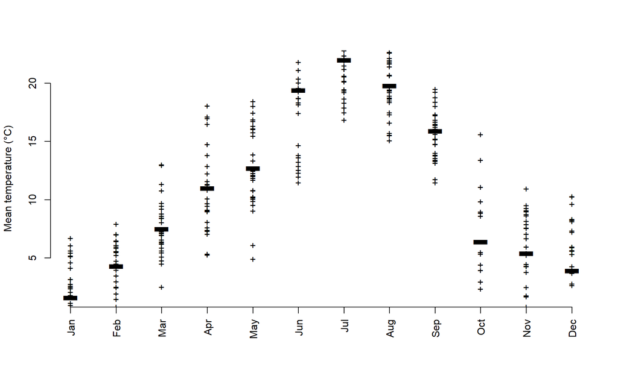

## Etape 09 : rep. graph.

```r
meanMois <- sapply(seq_along(bddMD), function(i){
  sapply(seq_along(bddMD[[i]]), function(j){
    mean(bddMD[[i]][[j]])
  })
})
plot(x = 1:12, y = myRef, axes = FALSE,
  pch = "-", cex = 5, xlab = "", ylim = c(0, 40),
  ylab = "Mean temperature (°C)")
axis(1, at = 1:12, labels = month.abb, las = 3)
axis(2)
points(
  x = rep(1:12, sapply(meanMois, length)) +
    rnorm(length(unlist(meanMois)), sd = 0.05),
  y = unlist(meanMois), pch = 1)
```

## Etape 09 : rep. graph.

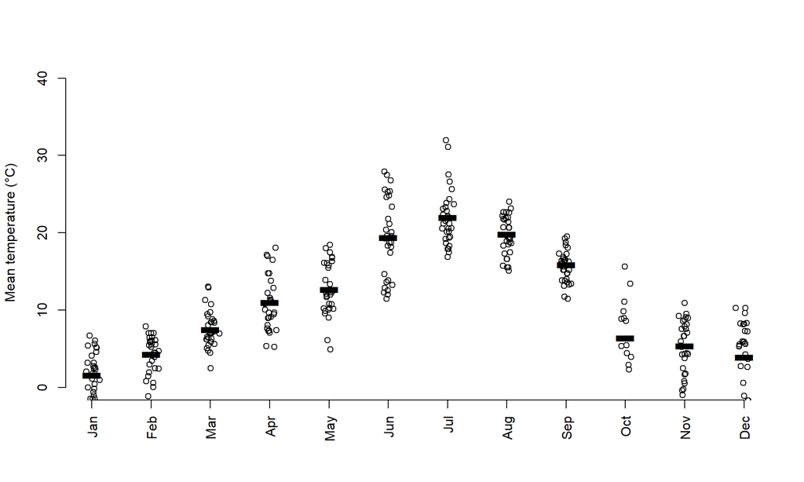

## Etape 09 : rep. graph.

```r
isSign <- unlist(pvalMois)
myCol <- vector(mode = "character", length = length(isSign))
myCol[isSign < 0.05] <- "red"
myCol[isSign >= 0.05] <- "green"
meanMois <- sapply(seq_along(bddMD), function(i){
  sapply(seq_along(bddMD[[i]]), function(j){
    mean(bddMD[[i]][[j]])
  })
})
plot(x = 1:12, y = myRef, axes = FALSE,
  pch = "-", cex = 5, xlab = "", ylim = c(0, 40),
  ylab = "Mean temperature (°C)")
axis(1, at = 1:12, labels = month.abb, las = 3)
axis(2)
points(
  x = rep(1:12, sapply(meanMois, length)) +
    rnorm(length(unlist(meanMois)), sd = 0.06),
  y = unlist(meanMois), pch = 16, col = myCol)
```

## Etape 09 : rep. graph.

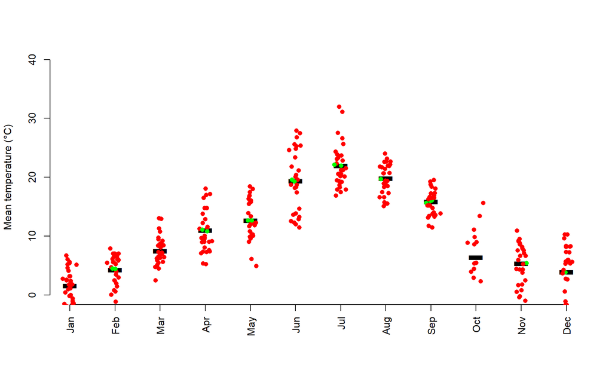

## Etape 10 : conclusion (suite)

Presque tous les jours ont une moyenne significativement différente de la valeur de référence mensuelle.

La valeur de référence mensuelle serait un très mauvais indicateur de la température des jours au sein d’un mois ?

**Plutôt que de comparer la moyenne de chaque jour à la valeur de référence mensuelle, que pourrions-nous tester ?**